# M8752 Pokročilé regresní modely II

- Show All Code
- Hide All Code
- View Source

Úloha ku skúške

Autor

Michaela Marčeková

Publikované

February 2, 2025

```r
library(tidyr)
library(ggplot2)
library(dplyr)
library(patchwork)
library(gtsummary)
library(data.table)
library(survival)
library(mgcv)
```

# Úprava dát

Dáta popisujú dobu prežitia pacientov s HIV od diagnózy AIDS. Z dát odstránime pacientov, ktorí sa nakazili neznámym (`NA`) alebo iným (`Other`) spôsobom.

```r
load("aidsdeath2.RData")
aidsdeath2 = aidsdeath2[!(is.na(mode)|(mode == "Other"))]
aidsdeath2[, mode := droplevels(mode)]
#head(aidsdeath2)
#summary(aidsdeath2)
```

Dáta upravíme tak, aby sa na nich dali odhadovať modely, v ktorých vystupuje čas. Rozdelíme ich na intervaly dĺžky 0.05 roku a vyberieme len tie počas prvých 10 rokov pozorovania.

```r
aidsdeath2split = as.data.table(survSplit(Surv(t1, t2, death) ~ cd4 + gender + mode + age0 + patient, data = aidsdeath2, cut = seq(0, 10, by = .05)), key = c("patient", "t1"))
setcolorder(aidsdeath2split, c("patient", "t1", "t2", "death"))
aidsdeath2split = aidsdeath2split[t2 <= 10]
```

```r
# Overenie rovnakych odhadov v Poissonovskej regresii pre povodne a rozdelene data podla casu
glm(death ~ offset(log(t2 - t1)) + cd4 + age0 + gender + mode, family = poisson, data = as.data.table(survSplit(Surv(t1, t2, death) ~ cd4 + gender + mode + age0 + patient, data = aidsdeath2, cut = seq(0, 10, by = 10)))[t2 <= 10]) # poisson. regrese z puvodnich dat ukoncenych v case 10
glm(death ~ offset(log(t2 - t1)) + cd4 + age0 + gender + mode, family = poisson, data = aidsdeath2split) # poisson. regrese z dat rozdelenych s krokem 0.05 ukoncenych v case 10
```

[output not shown]

# Popis dát

V dátovom súbore sa nachádzajú nasledujúce premenné:

| **Premenná** | **Typ** | **Popis** |
| --- | --- | --- |
| `patient` | ID | identifikátor pacienta |
| `gender` | M/F | pohlavie pacienta |
| `mode` | Heterosexual/IDU/MSM | pravdepodobný spôsob prenosu nákazy |
| `age0` | numerická [v rokoch] | vek pacienta, keď zahájil liečbu |
| `cd4` | numerická | indikátor stavu imunitného systému pacienta (v priebehu liečby sa mení vzhľadom na čas) |
| `t1`, `t2` | numerická [v rokoch od začiatku liečby] | časové intervaly, na ktorých pozorujeme zmenu stavu pacienta, a to úmrtie (premenná `death`) a stav imunitného systému (premenná `cd4`) |
| `death` | 0/1 | úmrtie pacienta |

# Chýbajúce hodnoty

V dátovom súbore sa nachádza cca 3000 chýbajúcich hodnôt premennej `cd4`, čo tvorí cca 7% tejto premennej.

```r
dat <- aidsdeath2split
round(colSums(is.na(dat))/nrow(aidsdeath2split), 4) # percento chybajucich hodnotot
```

```
patient      t1      t2   death     cd4  gender    mode    age0
 0.0000  0.0000  0.0000  0.0000  0.0733  0.0000  0.0000  0.0000
```

Chýbajúce hodnoty `cd4` sa nachádzajú u veľa peciantov, cca 37% pacientov, a preto nebudeme podstraňovať z dátového súboru všetky záznamy pre pacientov, ktorí majú aspoň jednu chýbajúcu hodnotu `cd4`.

```r
dat_missing <- dat[is.na(dat)[, 5], ]
# percento pacientov s chybajucim cd4
length(unique(dat_missing$patient))/length(unique(aidsdeath2split$patient))
```

```
[1] 0.373673
```

Chýbajúca hodnota `cd4` je problematická predovšetkým v tých záznamoch, kde u daného pacienta zároveň v rovnakom čase nastalo úmrtie. Pri fitovaní modelu by sa tieto záznamy odstránili, a teda by sme fitovali model bez toho, aby sme mu poskytli informáciu o tom, že u týchto pacientov nastalo úmrtie. Takýto pacienti tvoria takmer 1% celkového počtu pacientov v dátovom súbore (4 pacienti z celkovo 471 pacientov). Vzhľadom na veľké množstvo dát odstránime z dátového súboru záznamy pre týchto štyroch pacientov. Pri menšom počte dát by sme zvolili skôr nahradenie chýbajúcej hodnoty `cd4` poslednou známou hodnotou `cd4`, to však nepovažujeme za potrebné pri veľkom počte pacientov a záznamov, ktoré máme k dispozícii.

```r
# percento pacientov s chybajucim cd4 v case umrtia
nrow(dat_missing[death == 1])/length(unique(aidsdeath2split$patient))
```

```
[1] 0.008492569
```

Ostatné záznamy s chýbajúcim `cd4` tiež odstránime, ale ponecháme ostatné záznamy pre daných pacientov (tých, u ktorých v danom čase nenastalo úmrtie). Celkovo sme takto odstránili 3601 záznamov z celkových 46977, čo tvorí takmer 8% záznamov pôvodnej dátovej tabuľky `aidsdeath2split`.

```r
# vymazanie zaznamov s chybajucimi hodnotami
dat <- dat[!(is.na(dat)[, 5])][!(patient %in% dat_missing$patient[dat_missing$death == 1]), ]
# percento vymazanych zaznamov
(nrow(aidsdeath2split)- nrow(dat))/nrow(aidsdeath2split)
```

```
[1] 0.07665453
```

# Exploratívna analýza

Popisné charakteristiky pacientov sú uvedené v nasledujúcej tabuľke. Celkovo je pacientov 466, prevažujú muži a spôsoby nákazy majú približne rovnaké zastúpenie v dátach. Priemerný vek na začiatku liečby je 38 rokov. Zastúpenie pacientov, pre ktorých liečba skončila, respektíve neskončila úmrtím je približne rovnaké. Priemerný čas liečby do úmrtia pacienta (ak nastalo úmrtie) je 2.03 roku.

```r
# unique(aidsdeath2split$patient) |> length() # pocet pacientov
# sum(aidsdeath2split$death) # pocet umrti

patients <- dat |>
  mutate(time_death = if_else(death == 1, t1, NA)) |>
  select(patient, gender, mode, age0, death, time_death) |>
  group_by(patient, gender, mode, age0) |>
  summarise(death = max(death),
            time_death = last(time_death)) |>
  ungroup()

patients |>
  select(-patient) |>
  mutate(death = factor(death)) |>
  tbl_summary(
    type = where(is.numeric) ~ "continuous2",
    statistic = list(all_continuous() ~ c("{mean} ({sd})", "{min}, {max}"), all_categorical() ~ "{n} ({p}%)")
  )
```

| **Characteristic** | **N = 466** <sup>1</sup> |
| --- | --- |
| gender |  |
| M | 361 (77%) |
| F | 105 (23%) |
| mode |  |
| Heterosexual | 134 (29%) |
| IDU | 148 (32%) |
| MSM | 184 (39%) |
| age0 |  |
| Mean (SD) | 38 (10) |
| Min, Max | 18, 82 |
| death |  |
| 0 | 257 (55%) |
| 1 | 209 (45%) |
| time_death |  |
| Mean (SD) | 2.03 (1.92) |
| Min, Max | 0.00, 9.66 |
| Unknown | 257 |

<sup>1</sup> n (%)

V nasledujúcich tabuľkách vidíme zastúpenie pacientov, u ktorých nastalo, resp. nenastalo úmrtie v rôznych kategóriach jednotlivých premenných. Ženy majú menšie zastúpenie úmrtia, a preto by `gender` mohla byť významná premenná na modelovanie rizikovej funkcie. Pacienti s nákazou spôsobom `Heterosexual` majú tiež menšie zastúpenie úmrtia, a preto by `mode` mohla byť významná premenná na modelovanie rizikovej funkcie. V ostatných kategóriach nevidíme výrazne iné zastúpenie úmrtia pacientov.

```r
patients |>
  select(gender, death) |>
  mutate(death = factor(death)) |>
  tbl_summary(
    by = gender,
    type = where(is.numeric) ~ "continuous2",
    statistic = list(all_continuous() ~ c("{mean} ({sd})", "{min}, {max}"), all_categorical() ~ "{n} ({p}%)")
  )
```

| **Characteristic** | **M** N = 361 <sup>1</sup> | **F** N = 105 <sup>1</sup> |
| --- | --- | --- |
| death |  |  |
| 0 | 190 (53%) | 67 (64%) |
| 1 | 171 (47%) | 38 (36%) |

<sup>1</sup> n (%)

```r
patients |>
  select(mode, death) |>
  mutate(death = factor(death)) |>
  tbl_summary(
    by = mode,
    type = where(is.numeric) ~ "continuous2",
    statistic = list(all_continuous() ~ c("{mean} ({sd})", "{min}, {max}"), all_categorical() ~ "{n} ({p}%)")
  )
```

| **Characteristic** | **Heterosexual** N = 134 <sup>1</sup> | **IDU** N = 148 <sup>1</sup> | **MSM** N = 184 <sup>1</sup> |
| --- | --- | --- | --- |
| death |  |  |  |
| 0 | 95 (71%) | 60 (41%) | 102 (55%) |
| 1 | 39 (29%) | 88 (59%) | 82 (45%) |

<sup>1</sup> n (%)

V nasledujúcej tabuľke vidíme zastúpenie pacientov, u ktorých nastalo, resp. nenastalo úmrtie v rôznych kategóriach interakcie `gender` a `mode`. Interakcia môže byť významná, nakoľko vidíme, že ženy a mužy s nákazou `IDU` majú rôzne zastúpenie úmrtia.

```r
patients |>
  mutate(death = factor(death),
         gender_mode = interaction(gender, mode,
                                   sep = ":")) |>
  select(gender_mode, death) |>
  tbl_summary(
    by = gender_mode,
    type = where(is.numeric) ~ "continuous2",
    statistic = list(all_continuous() ~ c("{mean} ({sd})", "{min}, {max}"), all_categorical() ~ "{n} ({p}%)")
  )
```

| **Characteristic** | **M:Heterosexual** N = 81 <sup>1</sup> | **F:Heterosexual** N = 53 <sup>1</sup> | **M:IDU** N = 96 <sup>1</sup> | **F:IDU** N = 52 <sup>1</sup> | **M:MSM** N = 184 <sup>1</sup> | **F:MSM** N = 0 <sup>1</sup> |
| --- | --- | --- | --- | --- | --- | --- |
| death |  |  |  |  |  |  |
| 0 | 57 (70%) | 38 (72%) | 31 (32%) | 29 (56%) | 102 (55%) | 0 (NA%) |
| 1 | 24 (30%) | 15 (28%) | 65 (68%) | 23 (44%) | 82 (45%) | 0 (NA%) |

<sup>1</sup> n (%)

Na nasledujúcich obrázkoch sú histogramy `age0` pre pacientov, u ktorých nastalo respektíve nenastalo, úmrtie. Histogramy vyzerajú podobne, a preto sa zdá, že vek na začiatku liečby nemá významný vplyv na úmrtie pacienta.

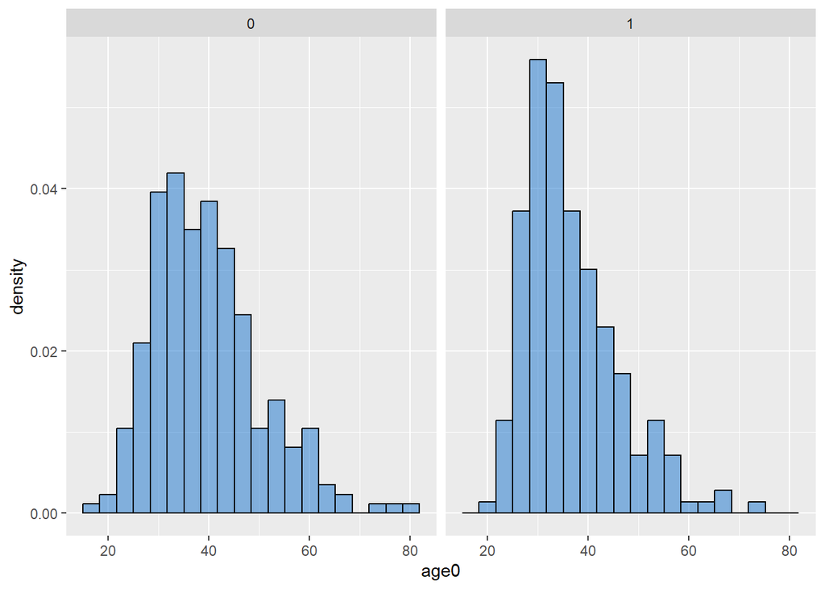

```r
patients |>
  select(age0, death) |>
  mutate(death = factor(death)) |>
  ggplot(aes(x = age0)) +
  geom_histogram(aes(y = after_stat(density)),
                 fill = 'dodgerblue3', alpha = 0.5,
                 colour = 'black', bins = 20) +
  facet_wrap(~death)
```

Na nasledujúcich obrázkoch sú histogramy `age0` pre pacientov, u ktorých nastalo, respektíve nenastalo, úmrtie a navyše rozdelené podľa pohlavia. Histogramy vyzerajú podobne pre ženy a mužov, ale môžeme si všimúť, že u žien s vyšším `age0` (>60) nenastáva úmrtie.

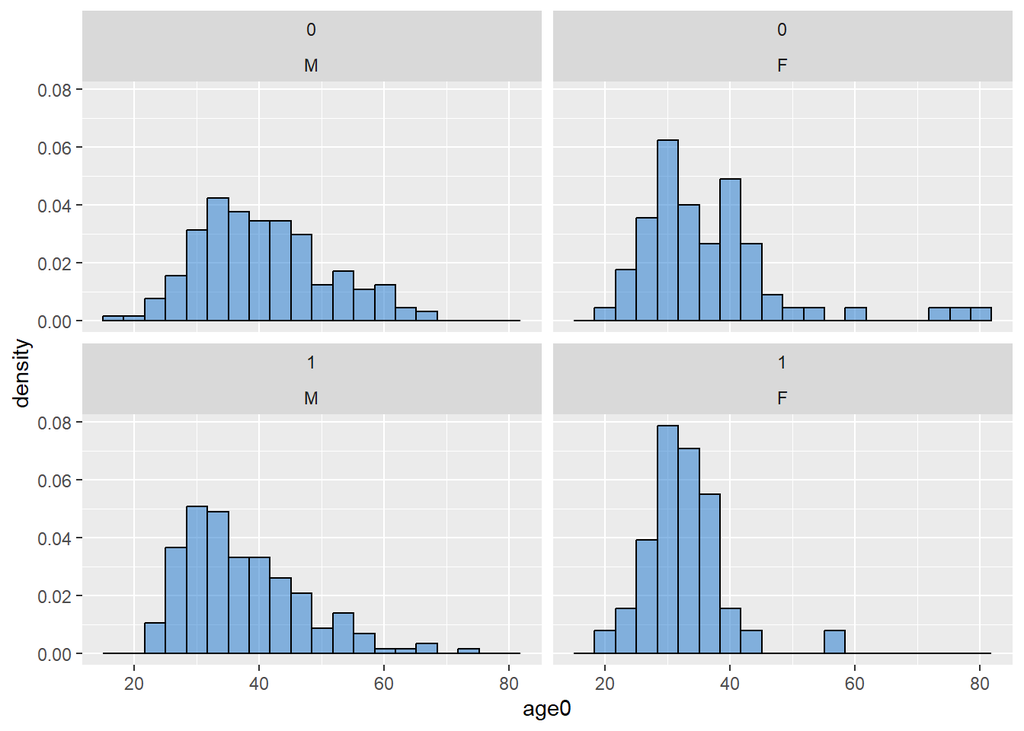

```r
patients |>
  select(age0, gender, death) |>
  mutate(death = factor(death)) |>
  ggplot(aes(x = age0)) +
  geom_histogram(aes(y = after_stat(density)),
                 fill = 'dodgerblue3', alpha = 0.5,
                 colour = 'black', bins = 20) +
  facet_wrap(~death + gender)
```

Na nasledujúcich obrázkoch sú histogramy `age0` pre pacientov, u ktorých nastalo, respektíve nenastalo, úmrtie a navyše rozdelené podľa `mode`. Histogramy vyzerajú podobne pre rôzne spôsoby nákazy, a preto sa zdá, že interakcia `ago0` a `mode0` nie je významná.

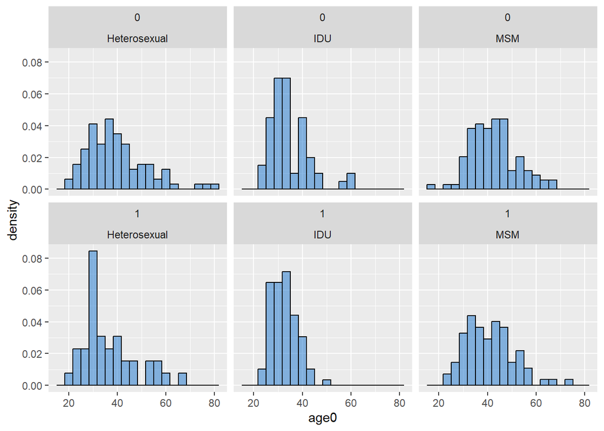

```r
patients |>
  select(age0, mode, death) |>
  mutate(death = factor(death)) |>
  ggplot(aes(x = age0)) +
  geom_histogram(aes(y = after_stat(density)),
                 fill = 'dodgerblue3', alpha = 0.5,
                 colour = 'black', bins = 20) +
  facet_wrap(~death + mode)
```

Na nasledujúcich grafoch je zobrazený indikátor stavu imunity `cd4` vzhľadom na čas od začiatku liečby pre jednotlivých pacientov. Pacienti sú rozdelený do dvoch grafov podľa toho, či u nich nastalo úmrtie. U pacientov, u ktorých nastalo úmrtie, pozorojeme nižšie a prevažne klesajúce honocty `cd4`. Na grafoch je vidieť, že interakcia `cd4` a času `t1` môže mať významný vplyv na rizikovú funkciu, keďže nízka honotna `cd4` na začiatku liečby je bežná, zatiaľ čo nízka hodnota `cd4` v pokročilom čase zvyšuje riziko úmrtia.

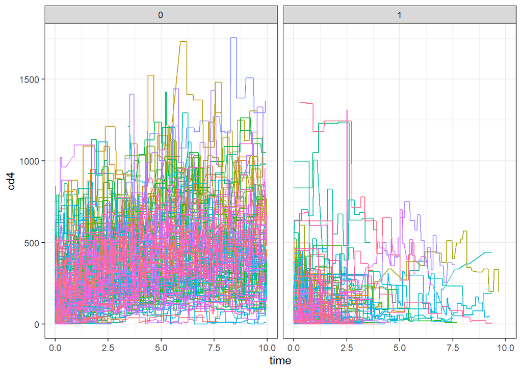

```r
dat2 <- dat |> mutate(time_death = if_else(death == 1, t1, NA))

patients2 <- patients[, c("patient", "time_death", "death")]
names(patients2)[3] <- "event"
dat2 <- left_join(dat, patients2,
                  by = join_by(patient))

theme_set(theme_bw())
ggplot(dat2,
       aes(x = t1, y = cd4, col = factor(patient))) +
  geom_line() +
  labs(x = "time",
       y = "cd4") +
  theme(legend.position = "none") +
  facet_wrap(~event)
```

Kvôli prehľadnosti sú tie isté grafy vykreslené ešte raz, iba pre menší počet pacientov z dátového súboru (celkovo 10 pacientov). Vertikálne čiary zobrazujú čas úmrtia.

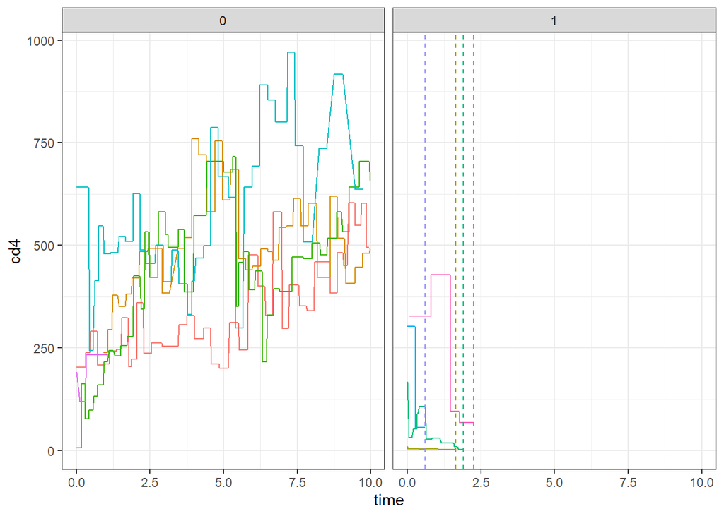

```r
ggplot(dat2[patient %in% patients$patient[c(1:10)]],
       aes(x = t1, y = cd4, col = factor(patient))) +
  geom_line() +
  #geom_point() +
  geom_vline(aes(xintercept = time_death,
                 col = factor(patient)),
             lty = "dashed") +
  labs(x = "time",
       y = "cd4") +
  theme(legend.position = "none") +
  facet_wrap(~event)
```

Na nasledujúcich grafoch je zobrazený indikátor stavu imunity `cd4` vzhľadom na čas od začiatku liečby pre jednotlivých pacientov. Pacienti sú rozdelený do viacerých skupín podľa toho, či u nich nastalo úmrtie a aký je pravdepodobný spôsob ich nákazy `mode`. V jednotlivých kategóriách premennej `mode` vidíme rôzny priebeh `cd4`.

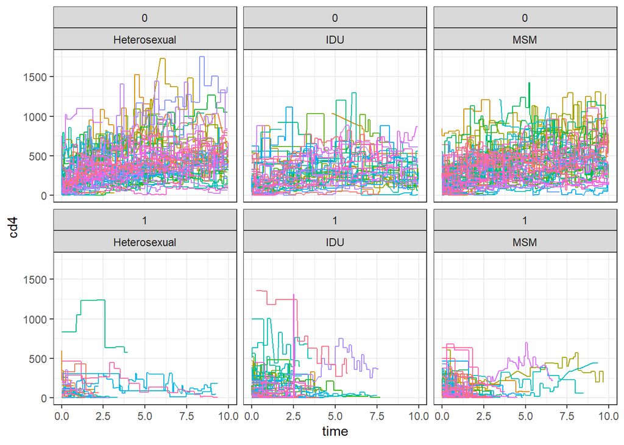

```r
ggplot(dat2,
       aes(x = t1, y = cd4, col = factor(patient))) +
  geom_line() +
  labs(x = "time",
       y = "cd4") +
  theme(legend.position = "none") +
  facet_wrap(~event + mode)
```

# 1 Poissonovský GAM

**Zadanie**

Pomocí balíčku `mgcv` odhadněte poissonovský GAM s kovariátami dostupnými v datech.

Predpokladáme, že všetky funkcie času sú približne konštantné na jednotlivých krátkych intervaloch od `t1` do `t2` a tieto hodnoty sa hladko menia v závislosti na polohe počiatku intervalu `t1`. Uvažujeme poissonovský zobecnený aditívny model (GAM)
$$\lambda(t;x) = \exp\{\beta_0(t) + f_1(t, x_1) + \cdots + f_p(t, x_p)\}$$
so závislou premennou `death`, offsetom `log(t2 - t1)` a so splinami s argumentom $t_1$, prípadne aj v interakcii s kovariátami.

Na modelovanie hladkej závislosti na čase môžeme použiť vo funkcii `gam` člen `s(t1, bs = "cr")`, teda kubický regresný spline. Aby sme v modeli zachytili vplyv kategoriálnych kovariát, pridávame členy `gender + mode` a modelujeme závislosť na čase zvlášť pre jednotlivé kategórie pomocou členov `s(t1, by = gender, bs = "cr")` a `s(t1, by = mode, bs = "cr")`. Do modelu ďalej pridávame vek na začiatku liečby `age0` a interakciu času `t1` a `age0` pomocou `s(age0, bs = "cr") + ti(t1, age0, bs = "cr")`, kde `ti` značí, že využívame bázu tenzorového súčinu. Závislosť na indikátore imunitného stavu `cd4` zahŕňame pomocou kubického splinu `s(cd4, bs = "cr")` a `ti(t1, cd4, bs = "cr")` na zahrnutie interakcie `cd4` a času `t1`.

Takto zostrojený model považujeme za “základný” a ďalej sme skúšali aj iné modely, kde sme pridávali interakcie premenných na základe exploratívnej analýzy alebo sme ho naopak zjednodušovali, ak interakcie nemali významný vplyv alebo nebolo potrebné modelovať niektoré premenné pomocou splinov. Modely fitujeme iba na menšej časti dát, konkrétne na 8007 záznamoch pre 100 náhodne vybraných pacientov z dátového súboru. Modely porovnávame pomocou AIC v nasledujúcej tabuľke, v ktorej ale uvádzame len najlepších pár modelov.

```r
set.seed(1)
patients_sample <- patients$patient[sample(100)]
dat_sample <- dat |> filter(
  patient %in% patients_sample
)


m1 <- gam(death ~ offset(log(t2 - t1)) +
            gender + mode +
            s(t1, by = gender, bs = "cr") +
            s(t1, by = mode, bs = "cr") +
            s(age0, bs = "cr") +
            ti(t1, age0, bs = "cr") +
            s(cd4, bs = "cr", k = 25) +
            ti(t1, cd4, bs = "cr"),
          family = poisson, data = dat_sample, method = "REML")

m2 <- gam(death ~ offset(log(t2 - t1)) +
            gender*mode +
            s(t1, by = interaction(gender, mode), bs = "cr") +
            s(age0, bs = "cr") +
            ti(t1, age0, bs = "cr") +
            s(cd4, bs = "cr", k = 25) +
            ti(t1, cd4, bs = "cr"),
          family = poisson, data = dat_sample, method = "REML")

m3 <- gam(death ~ offset(log(t2 - t1)) +
            gender + mode +
            s(t1, by = gender, bs = "cr") +
            s(t1, by = mode, bs = "cr") +
            s(age0, by = gender, bs = "cr") +
            ti(t1, age0, bs = "cr") +
            s(cd4, bs = "cr", k = 25) +
            ti(t1, cd4, bs = "cr"),
          family = poisson, data = dat_sample, method = "REML")

m4 <- gam(death ~ offset(log(t2 - t1)) +
            gender * mode +
            s(t1, by = interaction(gender, mode), bs = "cr") +
            s(age0, by = gender, bs = "cr") +
            ti(t1, age0, bs = "cr") +
            s(cd4, bs = "cr", k = 25) +
            ti(t1, cd4, bs = "cr"),
          family = poisson, data = dat_sample, method = "REML")

m5 <- gam(death ~ offset(log(t2 - t1)) +
            gender * mode +
            s(t1, by = interaction(gender, mode), bs = "cr") +
            s(age0, by = gender, bs = "cr") +
            s(cd4, bs = "cr", k = 25) +
            ti(t1, cd4, bs = "cr"),
          family = poisson, data = dat_sample, method = "REML")

m6 <- gam(death ~ offset(log(t2 - t1)) +
            gender * mode +
            s(t1, by = interaction(gender, mode), bs = "cr") +
            s(age0, by = gender, bs = "cr") +
            s(cd4, by = gender, bs = "cr", k = 25) +
            ti(t1, cd4, bs = "cr"),
          family = poisson, data = dat_sample, method = "REML")

m7 <- gam(death ~ offset(log(t2 - t1)) +
            gender * mode +
            s(t1, by = interaction(gender, mode), bs = "cr") +
            s(age0, by = gender, bs = "cr") +
            s(cd4, by = mode, bs = "cr", k = 25) +
            ti(t1, cd4, bs = "cr"),
          family = poisson, data = dat_sample, method = "REML")

m8 <- gam(death ~ offset(log(t2 - t1)) +
            gender + mode +
            s(t1, by = gender, bs = "cr") +
            s(t1, by = mode, bs = "cr") +
            s(age0, by = gender, bs = "cr") +
            s(cd4, bs = "cr", k = 25) +
            ti(t1, cd4, bs = "cr"),
          family = poisson, data = dat_sample, method = "REML")

m9 <- gam(death ~ offset(log(t2 - t1)) +
            gender + mode +
            s(t1, by = gender, bs = "cr") +
            s(t1, by = mode, bs = "cr") +
            s(age0, by = gender, bs = "cr") +
            s(cd4, by = gender, bs = "cr", k = 25) +
            ti(t1, cd4, bs = "cr"),
          family = poisson, data = dat_sample, method = "REML")

m10 <- gam(death ~ offset(log(t2 - t1)) +
            gender + mode +
            s(t1, by = gender, bs = "cr") +
            s(t1, by = mode, bs = "cr") +
            s(age0, by = gender, bs = "cr") +
            s(cd4, by = mode, bs = "cr", k = 25) +
            ti(t1, cd4, bs = "cr"),
          family = poisson, data = dat_sample, method = "REML")

m11 <- gam(death ~ offset(log(t2 - t1)) +
            s(t1, bs = "cr") +
            gender + mode +
            age0*gender +
            s(cd4, by = mode, bs = "cr", k = 25) +
            ti(t1, cd4, bs = "cr"),
          family = poisson, data = dat_sample, method = "REML")

m12 <- gam(death ~ offset(log(t2 - t1)) +
            s(t1, bs = "cr") +
            gender + mode +
            s(cd4, by = mode, bs = "cr", k = 25) +
            ti(t1, cd4, bs = "cr"),
          family = poisson, data = dat_sample, method = "REML")

m13 <- gam(death ~ offset(log(t2 - t1)) +
            s(t1, bs = "cr") +
            gender * mode +
            s(cd4, by = mode, bs = "cr", k = 25) +
            ti(t1, cd4, bs = "cr"),
          family = poisson, data = dat_sample, method = "REML")

m14 <- gam(death ~ offset(log(t2 - t1)) +
            s(t1, bs = "cr") +
            gender + mode +
            s(cd4, bs = "cr", k = 30) +
            ti(t1, cd4, bs = "cr"),
          family = poisson, data = dat_sample, method = "REML")

m15 <- gam(death ~ offset(log(t2 - t1)) +
            s(t1, bs = "cr") +
            gender*mode +
            s(cd4, bs = "cr", k = 30) +
            ti(t1, cd4, bs = "cr"),
          family = poisson, data = dat_sample, method = "REML")

m16 <- gam(death ~ offset(log(t2 - t1)) +
            s(t1, bs = "cr") +
            mode +
            gender * age0 +
            s(cd4, bs = "cr", k = 30) +
            ti(t1, cd4, bs = "cr"),
          family = poisson, data = dat_sample, method = "REML")

m17 <- gam(death ~ offset(log(t2 - t1)) +
            s(t1, bs = "cr") +
            mode + gender:mode +
            gender * age0 +
            s(cd4, bs = "cr", k = 30) +
            ti(t1, cd4, bs = "cr"),
          family = poisson, data = dat_sample, method = "REML")

aic_mod <- AIC(m1, m2, m3, m4, m5, m6, m7, m8, m9, m10,
               m11, m12, m13, m14, m15, m16, m17)
save(aic_mod, file = "aic_mod.RData")
```

```r
load("aic_mod.RData")
aic_mod[aic_mod$AIC < 640, ]
```

```
          df      AIC
m7  26.49004 637.2049
m10 25.01195 625.3743
m11 16.99956 639.7097
m12 14.75986 638.2478
m13 15.85142 638.4321
```

Podľa `AIC` je najvhodnejší model `m10`. Ďalej budeme pracovať s týmto modelom, ktorý si pomenujeme `mod1` a pre účely týchto úloh aj s modelom `mod2`, ktorý vytvoríme ako zovšeobecnenie modelu `mod1` tak, aby v ňom boli všetky kovariáty modelované pomocou splinov v interakcii s časom. Oba tieto modely `mod1` a `mod2` modelujú závislosť na `cd4` zvlášť pre rôzne kategórie `mode`, čas `t1` tiež a interakciu času `t1` a `cd4` modelujú bez ohľadu na kategóriu `mode`. Pridaním tohto rozlíšenia aj v ďalších splinoch sme dostali horšie modely (podľa `AIC`) a navyše ich fitovanie bolo výpočetne náročné. Oba modely fitneme znovu na väčšom množstve dát, konkrétne na polovici pacientov (233 pacientov, 20949 záznamov) kvôli výpočetnej náročnosti.

```r
set.seed(1)
patients_sample <- patients$patient[sample(233)]
dat_sample <- dat |> filter(
  patient %in% patients_sample
)

mod1 <- gam(death ~ offset(log(t2 - t1)) +
            gender + mode +
            s(t1, by = gender, bs = "cr") +
            s(t1, by = mode, bs = "cr") +
            s(age0, by = gender, bs = "cr") +
            s(cd4, by = mode, bs = "cr", k = 25) +
            ti(t1, cd4, bs = "cr"),
          family = poisson, data = dat_sample, method = "REML")

mod2 <- gam(death ~ offset(log(t2 - t1)) +
            gender + mode +
            s(t1, by = gender, bs = "cr") +
            s(t1, by = mode, bs = "cr") +
            s(age0, by = gender, bs = "cr") +
            ti(t1, age0, bs = "cr", k = 25) +
            s(cd4, by = mode, bs = "cr", k = 25) +
            ti(t1, cd4, bs = "cr"),
          family = poisson, data = dat_sample, method = "REML")

save(mod1, file = "mod1.RData")
save(mod2, file = "mod2.RData")
```

```r
load("mod1.RData")
load("mod2.RData")
AIC(mod1, mod2)
```

```
           df      AIC
mod1 27.61236 1287.753
mod2 28.99101 1288.814
```

V `summary` modelov `mod1` a `mod2` vidíme, že obsahujú veľa kovariát s nevýznamným efektom. V oboch modeloch sú významné spliny s argumentom `cd4` pre každú kategóriu `mode` zvlášť.

**mod1**

```r
summary(mod1)$p.table
```

```
              Estimate Std. Error    z value     Pr(>|z|)
(Intercept) -4.6600487  1.0384810 -4.4873702 7.210772e-06
genderF     -0.2221942  0.5304757 -0.4188583 6.753197e-01
modeIDU      1.6241161  1.2114350  1.3406548 1.800326e-01
modeMSM     -0.6189728  1.4062962 -0.4401440 6.598328e-01
```

```r
summary(mod1)$s.table
```

```
                             edf   Ref.df       Chi.sq      p-value
s(t1):genderM           1.000201 1.000307  0.910028198 3.402187e-01
s(t1):genderF           1.891751 2.370420  2.095978327 5.258850e-01
s(t1):modeHeterosexual  1.168446 1.759771  1.981834072 4.363378e-01
s(t1):modeIDU           2.257847 2.830811  2.909714577 4.362326e-01
s(t1):modeMSM           1.987528 2.448232  3.079216952 2.107070e-01
s(age0):genderM         1.524402 1.878195  2.230824371 3.896544e-01
s(age0):genderF         1.000412 1.000822  0.004524066 9.489713e-01
s(cd4):modeHeterosexual 1.458591 1.793256 13.563040123 1.016443e-02
s(cd4):modeIDU          3.296605 4.187543 27.871485096 1.790829e-05
s(cd4):modeMSM          1.204740 1.381872 39.720415492 1.355961e-04
ti(t1,cd4)              2.212745 2.961136  1.372116108 6.827663e-01
```

**mod2**

```r
summary(mod2)$p.table
```

```
              Estimate Std. Error    z value     Pr(>|z|)
(Intercept) -4.7066220  1.0591733 -4.4436753 8.843506e-06
genderF     -0.2188952  0.5341313 -0.4098154 6.819414e-01
modeIDU      1.5949846  1.2287260  1.2980799 1.942599e-01
modeMSM     -0.6673954  1.4237815 -0.4687485 6.392494e-01
```

```r
summary(mod2)$s.table
```

```
                             edf   Ref.df     Chi.sq      p-value
s(t1):genderM           1.000012 1.000019  0.9992529 3.174991e-01
s(t1):genderF           1.881166 2.356505  2.1341171 5.102480e-01
s(t1):modeHeterosexual  1.198050 1.796950  2.0566990 4.239619e-01
s(t1):modeIDU           2.277248 2.854791  2.8740101 4.466718e-01
s(t1):modeMSM           2.269638 2.830509  4.3982129 1.483919e-01
s(age0):genderM         1.574645 1.951950  2.6879068 3.048982e-01
s(age0):genderF         1.000064 1.000128  0.1601713 6.890581e-01
ti(t1,age0)             1.001528 1.002928  0.5321793 4.664507e-01
s(cd4):modeHeterosexual 1.510926 1.871925 14.1967292 5.905084e-03
s(cd4):modeIDU          3.304545 4.195606 28.8583941 1.178884e-05
s(cd4):modeMSM          1.173358 1.326128 37.4834184 1.079144e-04
ti(t1,cd4)              2.099507 2.803568  0.9016807 7.401499e-01
```

V modeloch sme skontrolovali vhodnosť zvolených bázových dimenzii. Parameter `k` ovplyvňuje zakrivenie splinu – pre malé hodnoty `k` je spline hladší, pre veľké hodnoty `k` je spline rozkmitanejší. Pomocou funkcie `k.check()` sme skontolovali, že `k` je vhodne zvolené (p-hodnoty sú väčšie ako 0.05).

**mod1**

```r
set.seed(0)
k.check(mod1)
```

```
                        k'      edf   k-index p-value
s(t1):genderM            9 1.000201 0.9517883  0.5000
s(t1):genderF            9 1.891751 0.9517883  0.5125
s(t1):modeHeterosexual   9 1.168446 0.9517883  0.4450
s(t1):modeIDU            9 2.257847 0.9517883  0.4625
s(t1):modeMSM            9 1.987528 0.9517883  0.4600
s(age0):genderM          9 1.524402 0.9491800  0.3325
s(age0):genderF          9 1.000412 0.9491800  0.3600
s(cd4):modeHeterosexual 24 1.458591 0.9336279  0.1000
s(cd4):modeIDU          24 3.296605 0.9336279  0.1100
s(cd4):modeMSM          24 1.204740 0.9336279  0.1075
ti(t1,cd4)              16 2.212745 0.9120883  0.1975
```

**mod2**

```r
set.seed(0)
k.check(mod2)
```

```
                         k'      edf   k-index p-value
s(t1):genderM             9 1.000012 0.9516271  0.4375
s(t1):genderF             9 1.881166 0.9516271  0.4700
s(t1):modeHeterosexual    9 1.198050 0.9516271  0.4225
s(t1):modeIDU             9 2.277248 0.9516271  0.4325
s(t1):modeMSM             9 2.269638 0.9516271  0.4150
s(age0):genderM           9 1.574645 0.9496494  0.3250
s(age0):genderF           9 1.000064 0.9496494  0.3575
ti(t1,age0)             576 1.001528 0.8933286  0.0575
s(cd4):modeHeterosexual  24 1.510926 0.9334281  0.1075
s(cd4):modeIDU           24 3.304545 0.9334281  0.1075
s(cd4):modeMSM           24 1.173358 0.9334281  0.1275
ti(t1,cd4)               16 2.099507 0.9108812  0.2100
```

Modely môžeme schématicky zapísať ako
$$\begin{aligned}
\texttt{mod1: }
\frac{\lambda(t_1;x)}{t_2 - t_1} =
\exp\bigl\{\beta_0
&+ \beta_1 \text{I}(\texttt{Gender} = \texttt{F})
\\
&+ \beta_2 \text{I}(\texttt{Mode} = \texttt{IDU})
+ \beta_3 \text{I}(\texttt{Mode} = \texttt{MSM})
\\
&+ s_1(t_1) \text{I}(\texttt{Gender} = \texttt{F})
+ s_2(t_1) \text{I}(\texttt{Gender} = \texttt{M})
\\
&+ s_3(t_1) \text{I}(\texttt{Mode} = \texttt{Heterosexual})
+ s_4(t_1) \text{I}(\texttt{Mode} = \texttt{IDU})
+ s_5(t_1) \text{I}(\texttt{Mode} = \texttt{MSM})
\\
&+ s_6(\texttt{Age0}) \text{I}(\texttt{Gender} = \texttt{F})
+ s_7(\texttt{Age0}) \text{I}(\texttt{Gender} = \texttt{M})
\\
&+ s_8(\texttt{cd4}) \text{I}(\texttt{Mode} = \texttt{Heterosexual})
+ s_9(\texttt{cd4}) \text{I}(\texttt{Mode} = \texttt{IDU})
+ s_{10}(\texttt{cd4}) \text{I}(\texttt{Mode} = \texttt{MSM})
\\
&+ s_{11}(t_1, \texttt{cd4})
\bigr\}
\\
\texttt{mod2: }
\frac{\lambda(t_1;x)}{t_2 - t_1} =
\exp\bigl\{\beta_0
&+ \beta_1 \text{I}(\texttt{Gender} = \texttt{F})
\\
&+ \beta_2 \text{I}(\texttt{Mode} = \texttt{IDU})
+ \beta_3 \text{I}(\texttt{Mode} = \texttt{MSM})
\\
&+ s_1(t_1) \text{I}(\texttt{Gender} = \texttt{F})
+ s_2(t_1) \text{I}(\texttt{Gender} = \texttt{M})
\\
&+ s_3(t_1) \text{I}(\texttt{Mode} = \texttt{Heterosexual})
+ s_4(t_1) \text{I}(\texttt{Mode} = \texttt{IDU})
+ s_5(t_1) \text{I}(\texttt{Mode} = \texttt{MSM})
\\
&+ s_6(\texttt{Age0}) \text{I}(\texttt{Gender} = \texttt{F})
+ s_7(\texttt{Age0}) \text{I}(\texttt{Gender} = \texttt{M})
+ s_8(t_1, \texttt{Age0})
\\
&+ s_9(\texttt{cd4}) \text{I}(\texttt{Mode} = \texttt{Heterosexual})
+ s_{10}(\texttt{cd4}) \text{I}(\texttt{Mode} = \texttt{IDU})
+ s_{11}(\texttt{cd4}) \text{I}(\texttt{Mode} = \texttt{MSM})
\\
&+ s_{12}(t_1, \texttt{cd4})
\bigr\}
\end{aligned}$$

Závislosť linku na kovariátach, ktoré modelujeme splinami, je vykreslená v nasledujúcich grafoch.

**mod1**

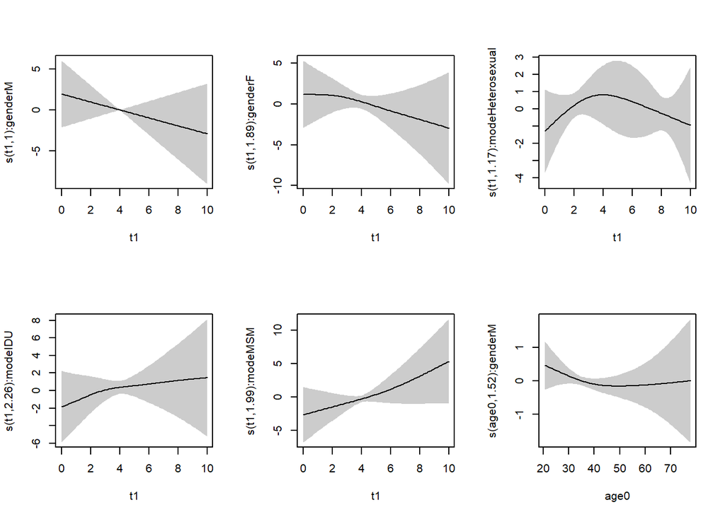

```r
par(mfrow = c(2, 3))
plot(mod1, shade = T, scale = 0)
```

[figure not shown]

```r
par(mfrow = c(1, 1))
```

**mod2**

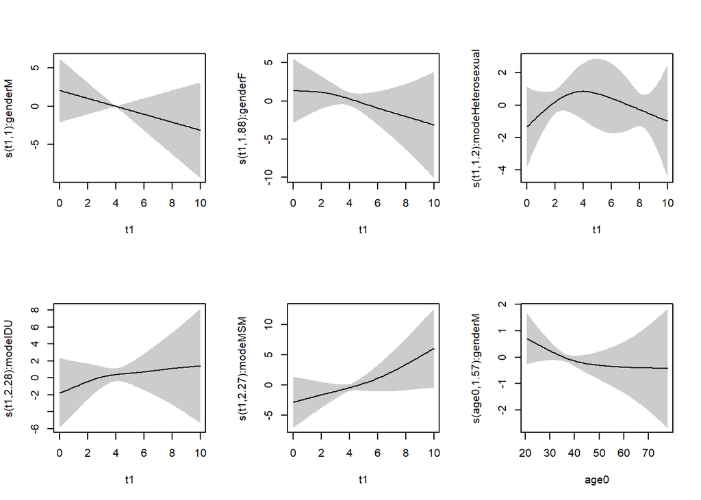

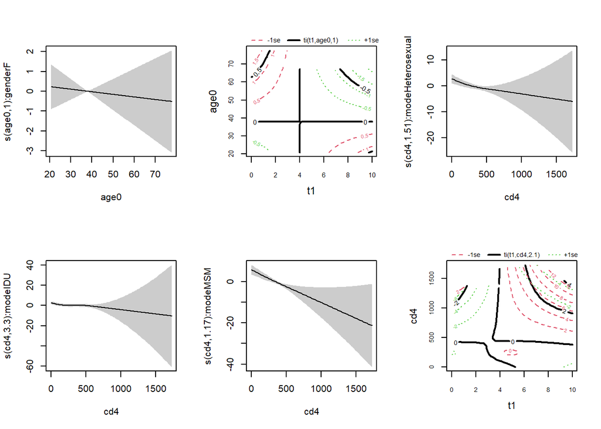

```r
par(mfrow = c(2, 3))
plot(mod2, shade = T, scale = 0)
```

```r
par(mfrow = c(1, 1))
```

# 2 Riziková funkcia ako funkcia času

**Zadanie**

S použitím tohoto modelu odhadněte rizikovou funkci v časech 0 až 10 let pro 30-letou ženu, která se nakazila při použití drog, a má hodnoty CD4 na úrovni 100, 300, 500. Zakreslete křivky do jednoho grafu spolu s konfidenčními intervaly. V grafu uveďte správné jednotky pro rizikovou funkci nebo ji přeškálujte, aby byla v událostech na 100 osobo-roků.

Podľa oboch modelov je riziko úmrtia vyššie pre nižšie hodnoty indikátoru stavu imunity `cd4`. S rastúcim časom riziko prevažne klesá, čo je zrejme spôsobené tým, že pri väčšine pacientov nastalo úmrtie relatívne skoro (cca počas tretieho roku liečby).

**mod1**

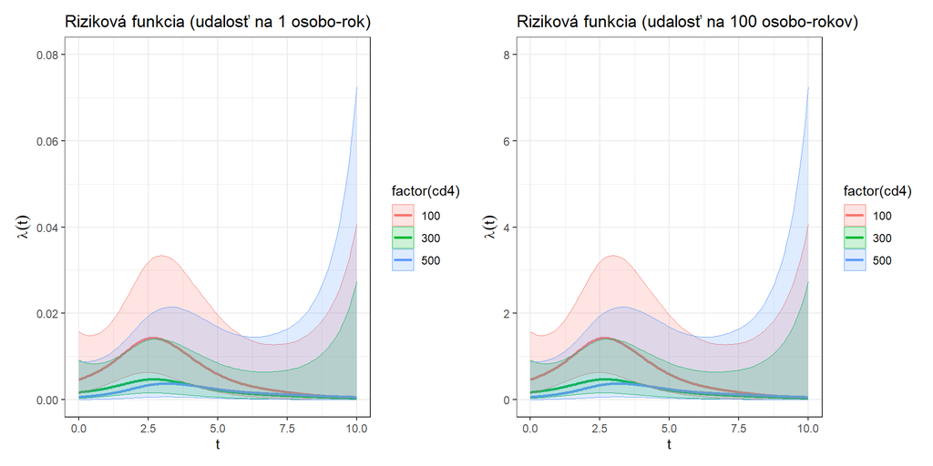

```r
new_dat <- expand_grid(
  cd4 = c(100, 300, 500),
  t1 = seq(0, 10, by = 0.05)) |>
  mutate(gender = "F",
         age0 = 30,
         mode = "IDU") |>
  cbind(t2 = seq(0.05, 10.05, by = 0.05)) |>
  select(t1, t2, gender, mode, age0, cd4)


# CI pre linearny prediktor
mod1_link_est <- predict(mod1, newdata = new_dat,
                         type = "link", se.fit = T)
mod1_link_ci <- cbind(
  est = mod1_link_est$fit,
  l95 = mod1_link_est$fit - 1.96 * mod1_link_est$se.fit,
  u95 = mod1_link_est$fit + 1.96 * mod1_link_est$se.fit
)

# CI pre lambda
mod1_lambda_ci <- poisson()$linkinv(mod1_link_ci)

new_dat_mod1 <- new_dat |> mutate(
  est = mod1_lambda_ci[, "est"],
  l95 = mod1_lambda_ci[, "l95"],
  u95 = mod1_lambda_ci[, "u95"])

p1 <- new_dat_mod1 |>
  ggplot(aes(x = t1, y = est, col = factor(cd4), fill = factor(cd4))) +
  geom_line(linewidth = 1) +
  geom_ribbon(alpha = 0.2, linewidth = 0.3,
              aes(ymin = l95, ymax = u95)) +
  ylim(c(0, 0.08)) +
  labs(x = "t",
       y = expression(lambda(t)),
       title = "Riziková funkcia (udalosť na 1 osobo-rok)")

p2 <- new_dat_mod1 |> mutate(
  est = 100*est,
  l95 = 100*l95,
  u95 = 100*u95) |>
  ggplot(aes(x = t1, y = est, col = factor(cd4), fill = factor(cd4))) +
  geom_line(linewidth = 1) +
  geom_ribbon(alpha = 0.2, linewidth = 0.3,
              aes(ymin = l95, ymax = u95)) +
  ylim(c(0, 8)) +
  labs(x = "t",
       y = expression(lambda(t)),
       title = "Riziková funkcia (udalosť na 100 osobo-rokov)")

p1 + p2
```

**mod2**

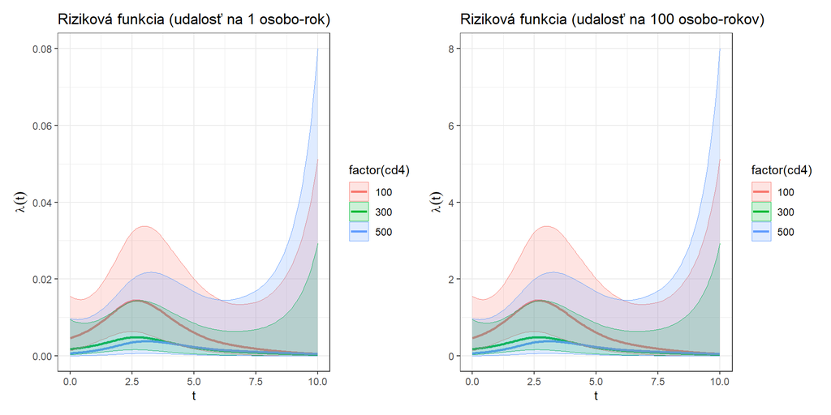

```r
new_dat <- expand_grid(
  cd4 = c(100, 300, 500),
  t1 = seq(0, 10, by = 0.05)) |>
  mutate(gender = "F",
         age0 = 30,
         mode = "IDU") |>
  cbind(t2 = seq(0.05, 10.05, by = 0.05)) |>
  select(t1, t2, gender, mode, age0, cd4)


# CI pre linearny prediktor
mod2_link_est <- predict(mod2, newdata = new_dat,
                         type = "link", se.fit = T)
mod2_link_ci <- cbind(
  est = mod2_link_est$fit,
  l95 = mod2_link_est$fit - 1.96 * mod2_link_est$se.fit,
  u95 = mod2_link_est$fit + 1.96 * mod2_link_est$se.fit
)

# CI pre lambda
mod2_lambda_ci <- poisson()$linkinv(mod2_link_ci)

new_dat_mod2 <- new_dat |> mutate(
  est = mod2_lambda_ci[, "est"],
  l95 = mod2_lambda_ci[, "l95"],
  u95 = mod2_lambda_ci[, "u95"])

p1 <- new_dat_mod2 |>
  ggplot(aes(x = t1, y = est, col = factor(cd4), fill = factor(cd4))) +
  geom_line(linewidth = 1) +
  geom_ribbon(alpha = 0.2, linewidth = 0.3,
              aes(ymin = l95, ymax = u95)) +
  ylim(c(0, 0.08)) +
  labs(x = "t",
       y = expression(lambda(t)),
       title = "Riziková funkcia (udalosť na 1 osobo-rok)")

p2 <- new_dat_mod2 |> mutate(
  est = 100*est,
  l95 = 100*l95,
  u95 = 100*u95) |>
  ggplot(aes(x = t1, y = est, col = factor(cd4), fill = factor(cd4))) +
  geom_line(linewidth = 1) +
  geom_ribbon(alpha = 0.2, linewidth = 0.3,
              aes(ymin = l95, ymax = u95)) +
  ylim(c(0, 8)) +
  labs(x = "t",
       y = expression(lambda(t)),
       title = "Riziková funkcia (udalosť na 100 osobo-rokov)")

p1 + p2
```

# 3 Riziková funkcia ako funkcia dvoch premenných

**Zadanie**

Znázorněte odhad rizikové funkce této osoby vhodným grafem (např. `image`, `contour`, `persp` apod.) funkce dvou proměnných (čas od 0 do 10, CD4 od 100 do 500).

Podľa oboch modelov pre rastúce hodnoty `cd4` prevažne klesá riziko úmrtia. Vzhľadom na čas riziko rastie približne do trtieho roku liečby, potom klesá.

**mod1**

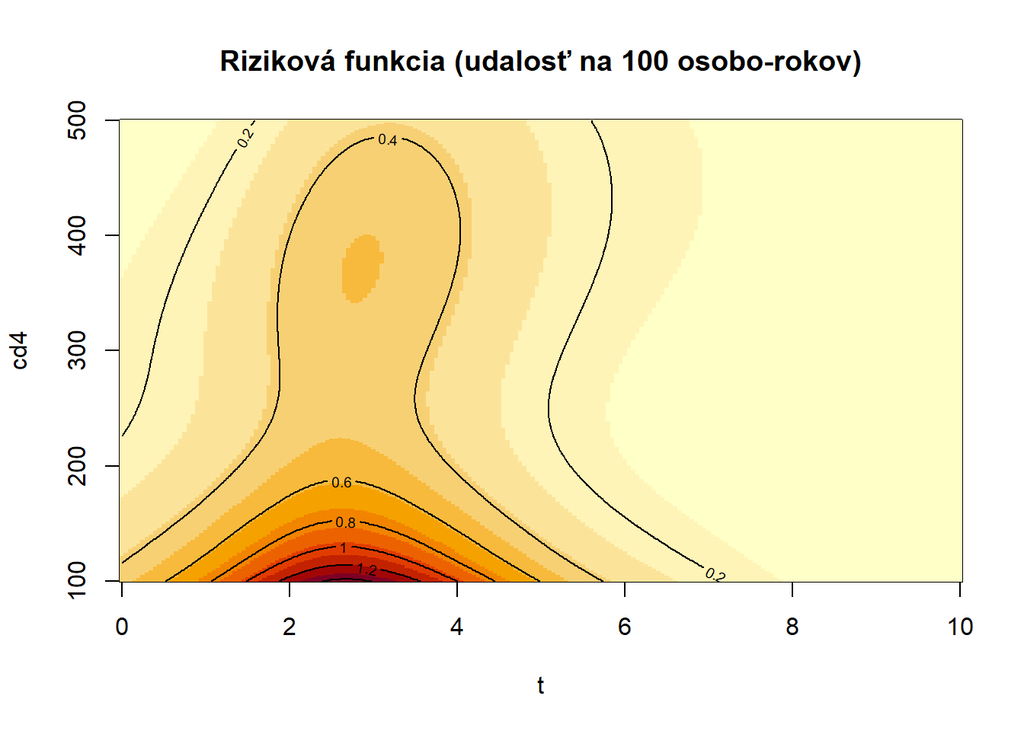

```r
cd4_seq <- seq(100, 500, by = 1)
t1_seq <- seq(0, 10, by = 0.05)
new_dat <- expand_grid(
  cd4 = cd4_seq,
  t1 = t1_seq) |>
  mutate(gender = "F",
         age0 = 30,
         mode = "IDU") |>
  cbind(t2 = seq(0.05, 10.05, by = 0.05)) |>
  select(t1, t2, gender, mode, age0, cd4)


# Odhad lambda
mod1_est <- predict(mod1, newdata = new_dat, type = "response")
mod1_est_mat <- matrix(mod1_est, nrow = length(t1_seq))

image(t1_seq, cd4_seq, 100*mod1_est_mat,
      xlab = "t", ylab = "cd4",
      main = "Riziková funkcia (udalosť na 100 osobo-rokov)")
contour(t1_seq, cd4_seq, 100*mod1_est_mat, add = T)
```

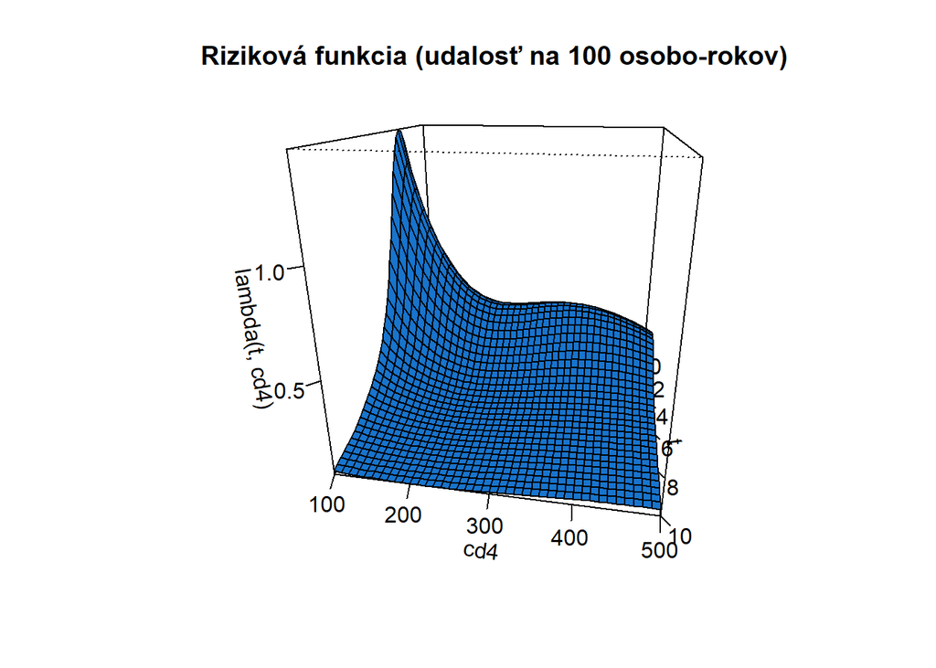

```r
persp(t1_seq[seq(1, 201, by = 5)],
      cd4_seq[seq(1, 401, by = 10)],
      100*mod1_est_mat[seq(1, 201, by = 5),
                       seq(1, 401, by = 10)],
      col = "dodgerblue3",
      ticktype = "detailed",
      theta = 100, phi = 20,
      xlab = "t", ylab = "cd4",
      zlab = expression(lambda(t, cd4)),
      main = "Riziková funkcia (udalosť na 100 osobo-rokov)")
```

**mod2**

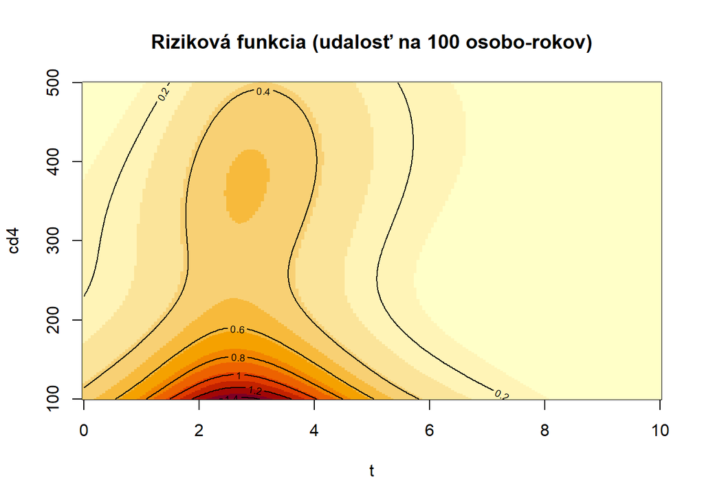

```r
cd4_seq <- seq(100, 500, by = 1)
t1_seq <- seq(0, 10, by = 0.05)
new_dat <- expand_grid(
  cd4 = cd4_seq,
  t1 = t1_seq) |>
  mutate(gender = "F",
         age0 = 30,
         mode = "IDU") |>
  cbind(t2 = seq(0.05, 10.05, by = 0.05)) |>
  select(t1, t2, gender, mode, age0, cd4)


# Odhad lambda
mod2_est <- predict(mod2, newdata = new_dat, type = "response")
mod2_est_mat <- matrix(mod2_est, nrow = length(t1_seq))

image(t1_seq, cd4_seq, 100*mod2_est_mat,
      xlab = "t", ylab = "cd4",
      main = "Riziková funkcia (udalosť na 100 osobo-rokov)")
contour(t1_seq, cd4_seq, 100*mod2_est_mat, add = T)
```

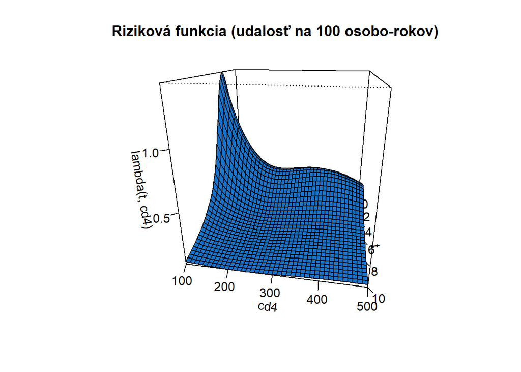

```r
persp(t1_seq[seq(1, 201, by = 5)],
      cd4_seq[seq(1, 401, by = 10)],
      100*mod2_est_mat[seq(1, 201, by = 5),
                       seq(1, 401, by = 10)],
      col = "dodgerblue3",
      ticktype = "detailed",
      theta = 100, phi = 20,
      xlab = "t", ylab = "cd4",
      zlab = expression(lambda(t, cd4)),
      main = "Riziková funkcia (udalosť na 100 osobo-rokov)")
```

# 4 Pomer rizika smrti

**Zadanie**

Pro uvažovanou pacientku odhadněte poměr rizika smrti při CD4 na úrovni 200 proti úrovni 500. Nakreslete graf odhadu spolu s konfidenčními intervaly. Při výpočtu poměru rizik budete potřebovat pracovat s rozdílem logaritmů rizikových funkcí a konfidenčním intervalem pro něj. *Nápověda*: Hodí se použít `predict` s `type="lpmatrix"` podobně jako v jednom z cvičení.

**mod1**

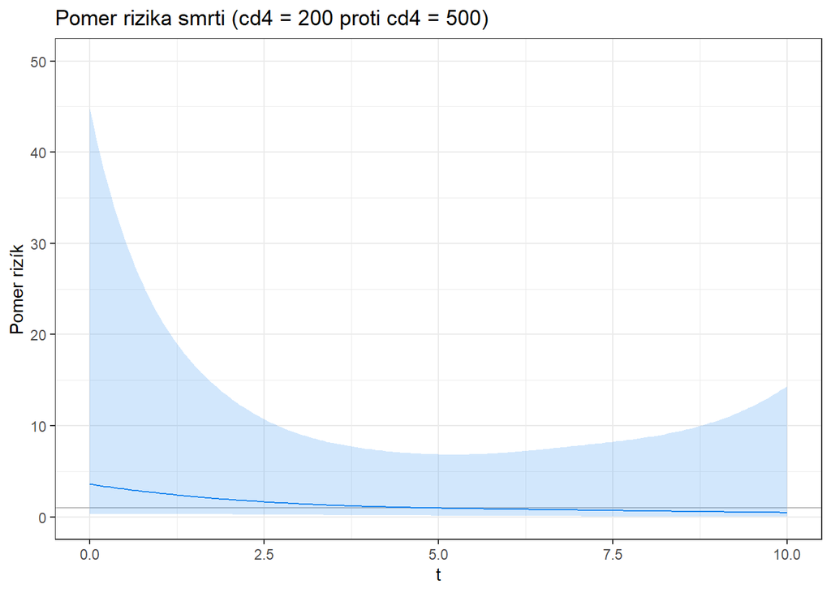

```r
new_dat <- expand_grid(
  cd4 = c(200, 500),
  t1 = seq(0, 10, by = 0.05)) |>
  mutate(gender = "F",
         age0 = 30,
         mode = "IDU") |>
  cbind(t2 = seq(0.05, 10.05, by = 0.05)) |>
  select(t1, t2, gender, mode, age0, cd4)

# matica linearnych prediktorov (bez offsetu)
lp_matrix <- predict(mod1, newdata = new_dat,
                         type = "lpmatrix")

# Odhad a CI
log_risk_diff_mat <- lp_matrix[new_dat$cd4 == 200, ] -
  lp_matrix[new_dat$cd4 == 500, ]
risk_diff_est <- log_risk_diff_mat %*% coef(mod1)
se_diff <- sqrt(diag(log_risk_diff_mat %*% vcov(mod1) %*% t(log_risk_diff_mat)))
l95 <- exp(risk_diff_est - 1.96 * se_diff)
u95 <- exp(risk_diff_est + 1.96 * se_diff)

# Vykreslenie
df_rr <- data.frame(
  t1 = t1_seq,
  risk_ratio = exp(risk_diff_est),
  l95 = l95,
  u95 = u95
)

df_rr |>
  ggplot(aes(x = t1, y = risk_ratio)) +
  geom_hline(yintercept = 1, col = "gray") +
  geom_line(color = "dodgerblue2") +
  geom_ribbon(aes(ymin = l95, ymax = u95),
              alpha = 0.2, fill = "dodgerblue2") +
  ylim(c(0, 50)) +
  labs(
    x = "t",
    y = "Pomer rizík",
    title = "Pomer rizika smrti (cd4 = 200 proti cd4 = 500)"
  )
```

**mod2**

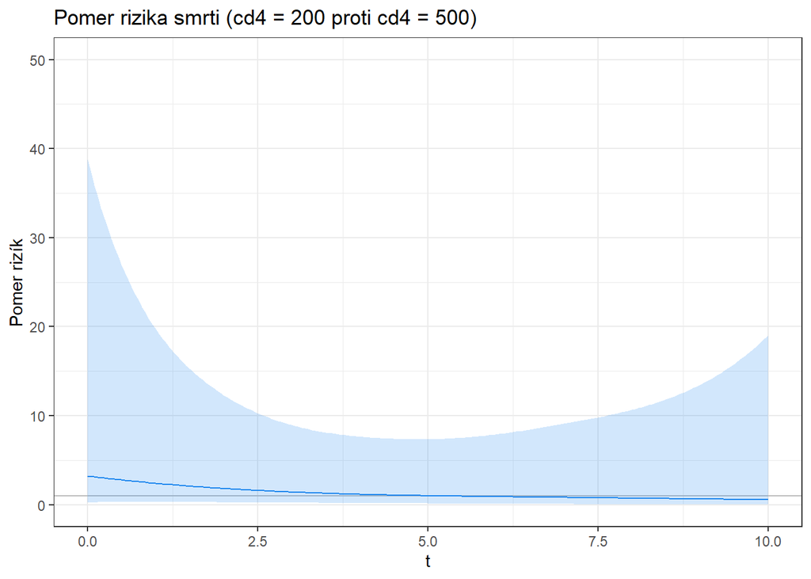

```r
new_dat <- expand_grid(
  cd4 = c(200, 500),
  t1 = seq(0, 10, by = 0.05)) |>
  mutate(gender = "F",
         age0 = 30,
         mode = "IDU") |>
  cbind(t2 = seq(0.05, 10.05, by = 0.05)) |>
  select(t1, t2, gender, mode, age0, cd4)

# matica linearnych prediktorov (bez offsetu)
lp_matrix <- predict(mod2, newdata = new_dat,
                         type = "lpmatrix")

# Odhad a CI
log_risk_diff_mat <- lp_matrix[new_dat$cd4 == 200, ] -
  lp_matrix[new_dat$cd4 == 500, ]
risk_diff_est <- log_risk_diff_mat %*% coef(mod2)
se_diff <- sqrt(diag(log_risk_diff_mat %*% vcov(mod2) %*% t(log_risk_diff_mat)))
l95 <- exp(risk_diff_est - 1.96 * se_diff)
u95 <- exp(risk_diff_est + 1.96 * se_diff)

# Vykreslenie
df_rr <- data.frame(
  t1 = t1_seq,
  risk_ratio = exp(risk_diff_est),
  l95 = l95,
  u95 = u95
)

df_rr |>
  ggplot(aes(x = t1, y = risk_ratio)) +
  geom_hline(yintercept = 1, col = "gray") +
  geom_line(color = "dodgerblue2") +
  geom_ribbon(aes(ymin = l95, ymax = u95),
              alpha = 0.2, fill = "dodgerblue2") +
  ylim(c(0, 50)) +
  labs(
    x = "t",
    y = "Pomer rizík",
    title = "Pomer rizika smrti (cd4 = 200 proti cd4 = 500)"
  )
```

# 5 Proporcionalita efektu kovariát

**Zadanie**

V rámci zobecněného aditivního modelu prozkoumejte pro jednotlivé kovariáty, zda je jejich efekt na rizikovou funkci proporcionální. Nápověda: Lze to udělat tak, že porovnáme model s modelem, v němž pro příslušnou kovariátu místo obecného efektu $f_j(t,x_j)$ je proporcionální (na čase nezávislý) efekt $s_j(x_j)$ nebo $\beta_j x_j$.

Vytvoríme modely `mod1_prop_X` a `mod2_prop_X` z modelov `mod1` a `mod2` vynechaním interakčného členu premennej `X` s časom a porovnáme ich s pôvodnými modelmi.

**mod1**

Model `mod1` obsahuje 3 prepenné v interakcii s časom, a preto vytvoríme 3 nové modely - `mod1_prop_gender`, `mod1_prop_mode`, `mod1_prop_cd4`. V tabuľke sú vypísané p-hodnoty, ktoré sme dostali ako výstup z `anova` pri porovnávaní s modelom `mod1`.

```r
mod1_prop_gender <- gam(death ~ offset(log(t2 - t1)) +
            gender + mode +
            s(t1, by = mode, bs = "cr") +
            s(age0, by = gender, bs = "cr") +
            s(cd4, by = mode, bs = "cr", k = 25) +
            ti(t1, cd4, bs = "cr"),
          family = poisson, data = dat_sample, method = "REML")
save(mod1_prop_gender, file = "mod1_prop_gender.RData")

mod1_prop_mode <- gam(death ~ offset(log(t2 - t1)) +
            gender + mode +
            s(t1, by = gender, bs = "cr") +
            s(age0, by = gender, bs = "cr") +
            s(cd4, by = mode, bs = "cr", k = 25) +
            ti(t1, cd4, bs = "cr"),
          family = poisson, data = dat_sample, method = "REML")
save(mod1_prop_mode, file = "mod1_prop_mode.RData")

mod1_prop_cd4 <- gam(death ~ offset(log(t2 - t1)) +
            gender + mode +
            s(t1, by = gender, bs = "cr") +
            s(t1, by = mode, bs = "cr") +
            s(age0, by = gender, bs = "cr") +
            s(cd4, by = mode, bs = "cr", k = 25),
          family = poisson, data = dat_sample, method = "REML")
save(mod1_prop_cd4, file = "mod1_prop_cd4.RData")
```

```r
load("mod1_prop_gender.RData")
load("mod1_prop_mode.RData")
load("mod1_prop_cd4.RData")
tab_anova <- data.frame(
  model = c("mod2_prop_gender",
            "mod2_prop_mode",
            "mod2_prop_cd4"),
  anova_pval = c(anova(mod1, mod1_prop_gender)$`Pr(>Chi)`[2],
                anova(mod1, mod1_prop_mode)$`Pr(>Chi)`[2],
                anova(mod1, mod1_prop_cd4)$`Pr(>Chi)`[2])
)
tab_anova
```

```
             model anova_pval
1 mod2_prop_gender  0.3492427
2   mod2_prop_mode  0.1765808
3    mod2_prop_cd4  0.3522558
```

Podľa `anova` môžeme prejsť k podmodelom, kde je efekt jednotlivých kovariát proporcionálny.

**mod2**

Model `mod2` obsahuje 4 premenné v interakcii s časom, a preto vytvoríme modely `mod2_prop_gender`, `mod2_prop_mode`, `mod2_prop_age0`, `mod2_prop_cd4`. V tabuľke sú vypísané p-hodnoty, ktoré sme dostali ako výstup z `anova` pri porovnávaní s modelom `mod2`.

```r
mod2_prop_gender <- gam(death ~ offset(log(t2 - t1)) +
            gender + mode +
            s(t1, by = mode, bs = "cr") +
            s(age0, by = gender, bs = "cr") +
            ti(t1, age0, bs = "cr", k = 25) +
            s(cd4, by = mode, bs = "cr", k = 25) +
            ti(t1, cd4, bs = "cr"),
          family = poisson, data = dat_sample, method = "REML")
save(mod2_prop_gender, file = "mod2_prop_gender.RData")

mod2_prop_mode <- gam(death ~ offset(log(t2 - t1)) +
            gender + mode +
            s(t1, by = gender, bs = "cr") +
            s(age0, by = gender, bs = "cr") +
            ti(t1, age0, bs = "cr", k = 25) +
            s(cd4, by = mode, bs = "cr", k = 25) +
            ti(t1, cd4, bs = "cr"),
          family = poisson, data = dat_sample, method = "REML")
save(mod2_prop_mode, file = "mod2_prop_mode.RData")

mod2_prop_age0 <- mod1
save(mod2_prop_age0, file = "mod2_prop_age0.RData")

mod2_prop_cd4 <- gam(death ~ offset(log(t2 - t1)) +
            gender + mode +
            s(t1, by = gender, bs = "cr") +
            s(t1, by = mode, bs = "cr") +
            s(age0, by = gender, bs = "cr") +
            ti(t1, age0, bs = "cr", k = 25) +
            s(cd4, by = mode, bs = "cr", k = 25),
          family = poisson, data = dat_sample, method = "REML")
save(mod2_prop_cd4, file = "mod2_prop_cd4.RData")
```

```r
load("mod2_prop_gender.RData")
load("mod2_prop_mode.RData")
load("mod2_prop_age0.RData")
load("mod2_prop_cd4.RData")
tab_anova <- data.frame(
  model = c("mod2_prop_gender",
            "mod2_prop_mode",
            "mod2_prop_age0",
            "mod2_prop_cd4"),
  anova_pval = c(anova(mod2, mod2_prop_gender)$`Pr(>Chi)`[2],
                anova(mod2, mod2_prop_mode)$`Pr(>Chi)`[2],
                anova(mod2, mod2_prop_age0)$`Pr(>Chi)`[2],
                anova(mod2, mod2_prop_cd4)$`Pr(>Chi)`[2])
)
tab_anova
```

```
             model anova_pval
1 mod2_prop_gender  0.3925275
2   mod2_prop_mode  0.1571092
3   mod2_prop_age0  0.3031721
4    mod2_prop_cd4  0.3942908
```

Podľa `anova` môžeme prejsť k podmodelom, kde je efekt jednotlivých kovariát proporcionálny.

# 6 Funkcia prežitia

**Zadanie**

Odhadněte funkci přežití v časech 0 až 10 let pro 30-letou ženu, která se nakazila při použití drog, a má hodnoty CD4 na úrovni 500. Připomeňme, že $S(t;x) = \exp\{−\int_0^t \lambda(u;x)du\}$.

Na výpočet funkcie prežitia počítame najprv kumulatívnu funkciu rizika $H(t;x) = \int_0^t \lambda(u;x)du$. Na výpočet integrálu používame aproximáciu pomocou delenia intervalu $[0, 10]$ bodmi $0 < 0.05 < 0.1 < \cdots < 10$ s krokom $0.05$, ktoré pre jednoduchosť označme $t_0 < t_1 < \cdots t_{200}$. Potom kumulatívnu funkciu rizika aproximujeme ako $H(t;x) = \sum_{t_i \leq t} \lambda(t_i;x) \times 0.05$.

**mod1**

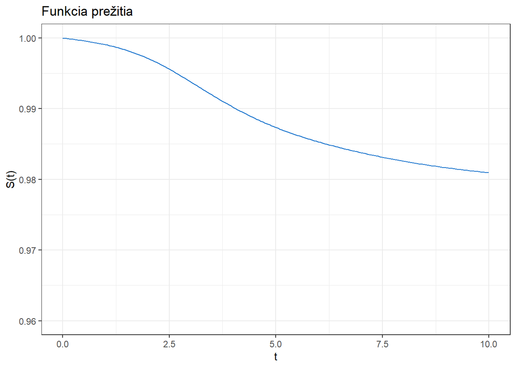

```r
new_dat <- data.frame(
  t1 = seq(0, 10, by = 0.05),
  t2 = seq(0.05, 10.05, by = 0.05),
  gender = "F",
  mode = "IDU",
  age0 = 30,
  cd4 = 500)

# Odhad rizkikovej funkcie lambda
lambda_est <- predict(mod1, newdata = new_dat, type = "response")

# Odhad kumulativnej funkcie rizika H
cum_hazard <- cumsum(lambda_est) * 0.05

# Odhad funkcie prezitia S
surv_est_mod1 <- exp(-cum_hazard)

# Vykreslenie
df_surv <- data.frame(
  t1 = t1_seq,
  surv_est = surv_est_mod1
)
df_surv |>
  ggplot(aes(x = t1, y = surv_est)) +
  geom_line(color = "dodgerblue3") +
  ylim(0.96, 1) +
  labs(
    x = "t",
    y = "S(t)",
    title = "Funkcia prežitia"
  )
```

**mod2**

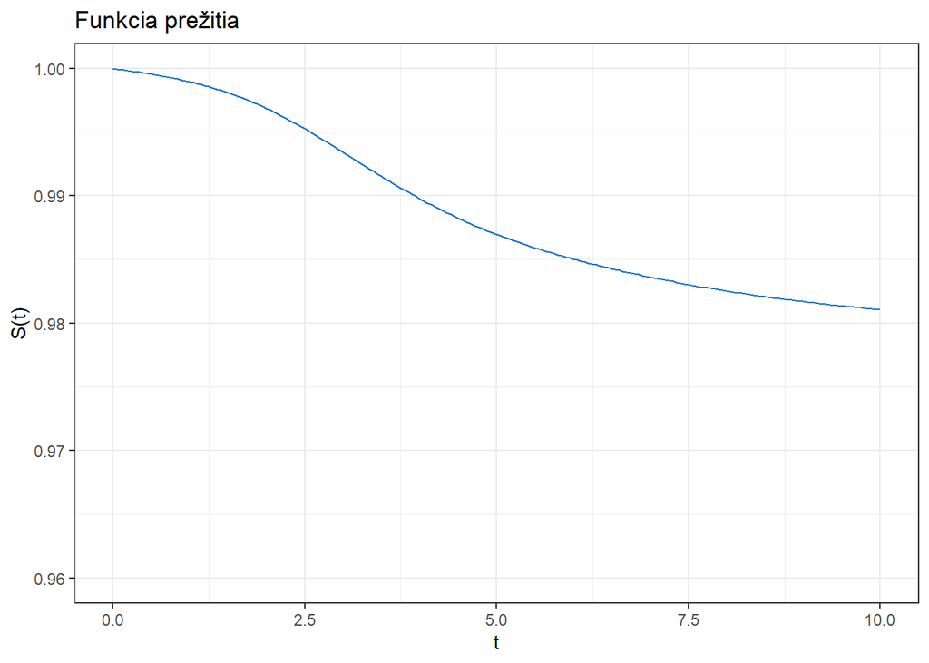

```r
new_dat <- data.frame(
  t1 = seq(0, 10, by = 0.05),
  t2 = seq(0.05, 10.05, by = 0.05),
  gender = "F",
  mode = "IDU",
  age0 = 30,
  cd4 = 500)

# Odhad rizkikovej funkcie lambda
lambda_est <- predict(mod2, newdata = new_dat, type = "response")

# Odhad kumulativnej funkcie rizika H
cum_hazard <- cumsum(lambda_est) * 0.05

# Odhad funkcie prezitia S
surv_est_mod2 <- exp(-cum_hazard)

# Vykreslenie
df_surv <- data.frame(
  t1 = t1_seq,
  surv_est = surv_est_mod2
)
df_surv |>
  ggplot(aes(x = t1, y = surv_est)) +
  geom_line(color = "dodgerblue3") +
  ylim(0.96, 1) +
  labs(
    x = "t",
    y = "S(t)",
    title = "Funkcia prežitia"
  )
```

# 7 Konfidenčné intervaly funkcie prežitia

**Zadanie**

*Doplňkový (nepovinný) úkol*. Přidejte konfidenční intervaly pro funkci přežití. *Nápověda*: Funkce přežití závisí komplikovaným nelineárním způsobem na splinových koeficientech z lineárního prediktoru, které se odhadují. Neurčitost odhadu funkce přežití se nejlépe analyzuje pomocí simulace z (aproximace) rozdělení odhadů koeficientů (připomeňme, že rozdělení odhadů odpovídá aposteriornímu rozdělení při bayesovském pohledu na splinové vyhlazování). Lze buď simulovat z asymptotické normální aproximace aposteriorního rozdělení s bayesovskou kovarianční maticí (z `vcov`) nebo z aposteriorního rozdělení pomocí Metropolis–Hastingsova algoritmu. Pro implementaci obou postupů se lze inspirovat v helpu k funkci `gam.mh`. Pro každou nasimulovanou realizaci koeficientů se spočítá odpovídající funkce přežití. Z výsledného souboru několika stovek až tisíců nasimulovaných funkcí přežití pak lze spočítat konfidenční intervaly nebo lze několik desítek nasimulovaných funkcí nakreslit spolu s bodovým odhadem funkce přežití pro ilustraci neurčitosti odhadu.

**mod1**

Pre model `mod1` robíme vzorky parametrov pomocou dvoch spôsobov – pomocou asympoticky normalnej aproximacie aposteriorneho rozdelenia a pomocou Metropolis-Hastings algoritmu. Miera prijatia M-H algoritmu je uvedená ako nasledujúci výstup.

```r
## Vzorkovanie odhadnutych koeficientov v modeli
set.seed(1)
n <- 10000 # velkost vzorky
# Pomocou asympoticky normalnej aproximacie aposteriorneho rozdelenia koeficientov
beta1 <- rmvn(n, coef(mod1), vcov(mod1))
# Pomocou Metropolis-Hastings algoritmu
beta2_MH <- gam.mh(mod1, ns = 2*n, thin = 2, rw.scale = 0.04)
data.frame(Random_Walk_Acceptance_Rate = beta2_MH$rw.accept)
```

```
  Random_Walk_Acceptance_Rate
1                     0.21355
```

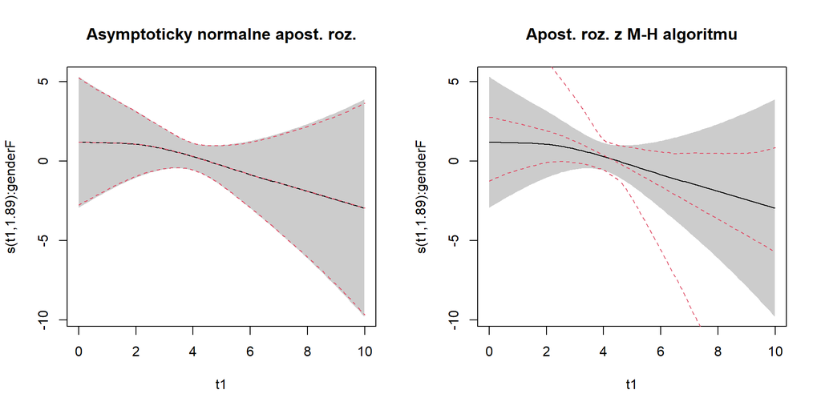

```r
beta2 <- beta2_MH$bs
# kandidatske koeficienty su generovane s kov. mat. prenasobenou rw.scale = 0.04 (su "blizsie" k aktualnym hodnotam)
# "prerezeme" vzorku na kazde thin = 2 -he pozorovanie (na zmiernenie zavislosti medzi vzorkovanymi koeficientami)

# Kvalita aproximacie
# Porovnanie CI pre spline casu pre Female
new_dat <- data.frame(
  t1 = seq(0, 10, by = 0.05),
  t2 = seq(0.05, 10.05, by = 0.05),
  gender = "F",
  mode = "IDU",
  age0 = 30,
  cd4 = 500)
X <- predict(mod1, newdata = new_dat, type = "lpmatrix")
# Asymptoticky normalne aposteriorne rozdelenie
par(mfrow = c(1, 2))
plot(mod1, select = 2, scale = 0, scheme = 1,
     main = "Asymptoticky normalne apost. roz.")
ii <- mod1$smooth[[2]]$first.para:mod1$smooth[[2]]$last.para
ff1 <- X[, ii] %*% t(beta1[, ii])
fq1 <- apply(ff1, 1, quantile, probs = c(.025,.975))
lines(new_dat$t1, fq1[1, ], col = 2, lty = 2)
lines(new_dat$t1, fq1[2, ], col = 2, lty = 2)
lines(new_dat$t1, apply(ff1, 1, mean), col = 2, lty = 2)
# Aposteriorne rozdelenie z M-H algoritmu
plot(mod1, select = 2, scale = 0, scheme = 1,
     main = "Apost. roz. z M-H algoritmu")
ii <- mod1$smooth[[2]]$first.para:mod1$smooth[[2]]$last.para
ff2 <- X[, ii] %*% t(beta2[, ii])
fq2 <- apply(ff2, 1, quantile, probs = c(.025,.975))
lines(new_dat$t1, fq2[1, ], col = 2, lty = 2)
lines(new_dat$t1, fq2[2, ], col = 2, lty = 2)
lines(new_dat$t1, apply(ff2, 1, mean), col = 2, lty = 2)
```

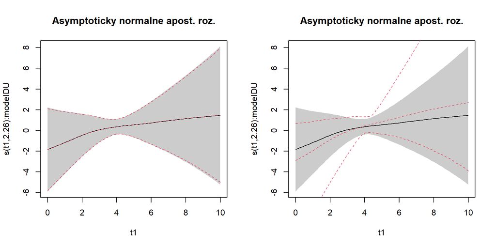

```r
par(mfrow = c(1, 1))

# Spline casu pre IDU
# Asymptoticky normalne aposteriorne rozdelenie
par(mfrow = c(1, 2))
plot(mod1, select = 4, scale = 0, scheme = 1,
     main = "Asymptoticky normalne apost. roz.")
ii <- mod1$smooth[[4]]$first.para:mod1$smooth[[4]]$last.para
ff1 <- X[, ii] %*% t(beta1[, ii])
fq1 <- apply(ff1, 1, quantile, probs = c(.025,.975))
lines(new_dat$t1, fq1[1, ], col = 2, lty = 2)
lines(new_dat$t1, fq1[2, ], col = 2, lty = 2)
lines(new_dat$t1, apply(ff1, 1, mean), col = 2, lty = 2)
# Aposteriorne rozdelenie z M-H algoritmu
plot(mod1, select = 4, scale = 0, scheme = 1,
     main = "Asymptoticky normalne apost. roz.")
ii <- mod1$smooth[[4]]$first.para:mod1$smooth[[4]]$last.para
ff1 <- X[, ii] %*% t(beta2[, ii])
fq1 <- apply(ff1, 1, quantile, probs = c(.025,.975))
lines(new_dat$t1, fq1[1, ], col = 2, lty = 2)
lines(new_dat$t1, fq1[2, ], col = 2, lty = 2)
lines(new_dat$t1, apply(ff1, 1, mean), col = 2, lty = 2)
```

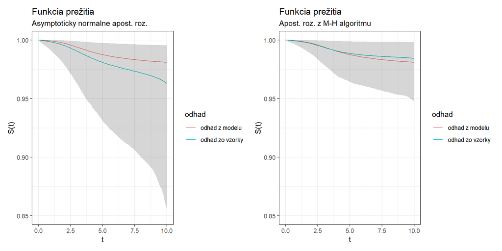

```r
par(mfrow = c(1, 1))

# Vzorka rizikovej funkcie lambda
linear_predictor_sample <- X %*% t(beta1)
lambda_sample <- exp(linear_predictor_sample) * 0.05
# nasobenie 0.05 kvoli offsetu
linear_predictor_sample_MH <- X %*% t(beta2)
lambda_sample_MH <- exp(linear_predictor_sample_MH) * 0.05

# Vzorka kumulativnej funkcie rizika H
cum_hazard_sample <- apply(lambda_sample, 2, cumsum) * 0.05
cum_hazard_sample_MH <- apply(lambda_sample_MH, 2, cumsum) * 0.05

# Vzorka funkcie prezitia S
surv_sample <- exp(-cum_hazard_sample)
surv_sample_MH <- exp(-cum_hazard_sample_MH)

# Vykreslenie 1
df_surv_est <- data.frame(
  t1 = c(t1_seq, t1_seq),
  surv_est = c(surv_est_mod1, apply(surv_sample, 1, mean)),
  odhad = rep(c("odhad z modelu", "odhad zo vzorky"),
              each = length(t1_seq))
)
df_surv_CI <- data.frame(
  t1 = t1_seq,
  surv_l95 = apply(surv_sample, 1, quantile, probs = .025),
  surv_u95 = apply(surv_sample, 1, quantile, probs = .975)
)
p1 <- df_surv_est |>
  ggplot(aes(x = t1, y = surv_est, color = odhad)) +
  geom_step() +
  geom_ribbon(data = df_surv_CI,
              aes(x = t1, ymin = surv_l95, ymax = surv_u95),
              alpha = 0.2,
              inherit.aes = FALSE) +
  ylim(c(0.85, 1)) +
  labs(
    x = "t",
    y = "S(t)",
    title = "Funkcia prežitia",
    subtitle = "Asymptoticky normalne apost. roz.") +
  theme_bw()

# Vykreslenie 2 (MH)
df_surv_est <- data.frame(
  t1 = c(t1_seq, t1_seq),
  surv_est = c(surv_est_mod1, apply(surv_sample_MH, 1, mean)),
  odhad = rep(c("odhad z modelu", "odhad zo vzorky"),
              each = length(t1_seq))
)
df_surv_CI <- data.frame(
  t1 = t1_seq,
  surv_l95 = apply(surv_sample_MH, 1, quantile, probs = .025),
  surv_u95 = apply(surv_sample_MH, 1, quantile, probs = .975)
)
p2 <- df_surv_est |>
  ggplot(aes(x = t1, y = surv_est, color = odhad)) +
  geom_step() +
  geom_ribbon(data = df_surv_CI,
              aes(x = t1, ymin = surv_l95, ymax = surv_u95),
              alpha = 0.2,
              inherit.aes = FALSE) +
  ylim(c(0.85, 1)) +
  labs(
    x = "t",
    y = "S(t)",
    title = "Funkcia prežitia",
    subtitle = "Apost. roz. z M-H algoritmu") +
  theme_bw()

p1 + p2
```

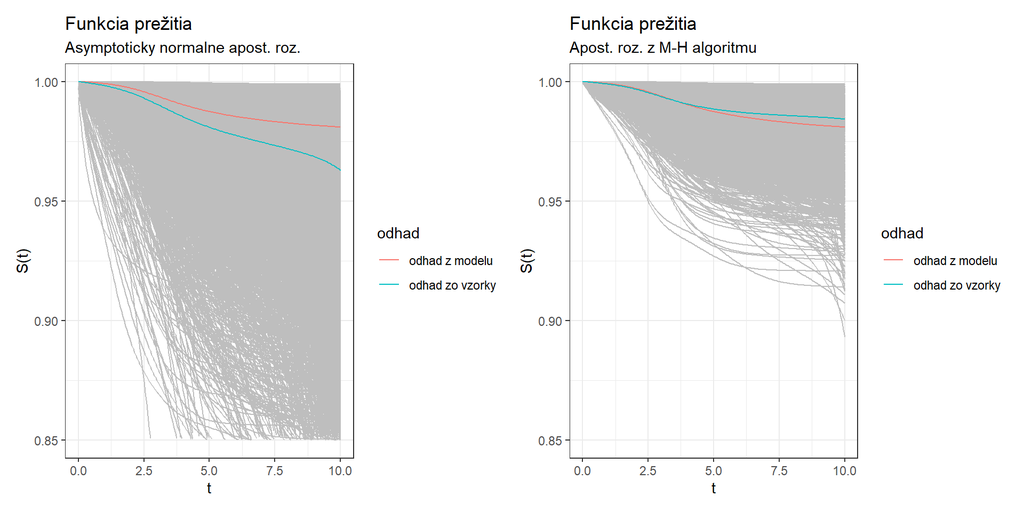

```r
# Vykreslenie 1
df_surv_est <- data.frame(
  t1 = c(t1_seq, t1_seq),
  surv_est = c(surv_est_mod1, apply(surv_sample, 1, mean)),
  odhad = rep(c("odhad z modelu", "odhad zo vzorky"),
              each = length(t1_seq))
)
df_surv_sample <- data.frame(
  t1 = t1_seq,
  surv = c(surv_sample),
  sample = rep(1:dim(surv_sample)[2], each = dim(surv_sample)[1])
)
p1 <- df_surv_sample |>
  ggplot(aes(x = t1, y = surv, group = sample)) +
  geom_line(color = "gray") +
  geom_step(data = df_surv_est,
            aes(x = t1, y = surv_est, color = odhad),
            inherit.aes = FALSE) +
  ylim(c(0.85, 1)) +
  labs(
    x = "t",
    y = "S(t)",
    title = "Funkcia prežitia",
    subtitle = "Asymptoticky normalne apost. roz.") +
  theme_bw()

# Vykreslenie 2 (MH)
df_surv_est <- data.frame(
  t1 = c(t1_seq, t1_seq),
  surv_est = c(surv_est_mod1, apply(surv_sample_MH, 1, mean)),
  odhad = rep(c("odhad z modelu", "odhad zo vzorky"),
              each = length(t1_seq))
)
df_surv_sample <- data.frame(
  t1 = t1_seq,
  surv = c(surv_sample_MH),
  sample = rep(1:dim(surv_sample_MH)[2], each = dim(surv_sample_MH)[1])
)
p2 <- df_surv_sample |>
  ggplot(aes(x = t1, y = surv, group = sample)) +
  geom_line(color = "gray") +
  geom_step(data = df_surv_est,
            aes(x = t1, y = surv_est, color = odhad),
            inherit.aes = FALSE) +
  ylim(c(0.85, 1)) +
  labs(
    x = "t",
    y = "S(t)",
    title = "Funkcia prežitia",
    subtitle = "Apost. roz. z M-H algoritmu") +
  theme_bw()

p1 + p2
```

**mod2**

Pre model `mod2` robíme vzorky parametrov iba pomocou asympoticky normalnej aproximacie aposteriorneho rozdelenia. Algoritmus Metropolis-Hastings sme hlásil chybovú správu `Error in chol.default(V) : the leading minor of order 31 is not positive`.

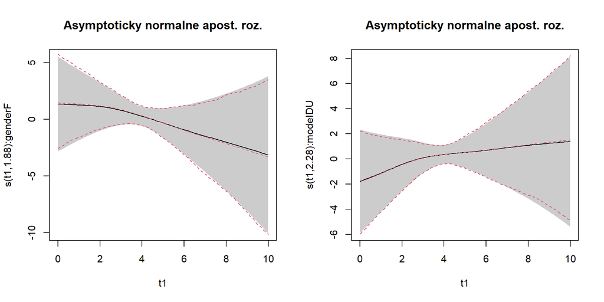

```r
## Vzorkovanie odhadnutych koeficientov v modeli
set.seed(1)
n <- 1000 # velkost vzorky
# Pomocou asympoticky normalnej aproximacie aposteriorneho rozdelenia koeficientov
beta1 <- rmvn(n, coef(mod2), vcov(mod2))
# Pomocou Metropolis-Hastings algoritmu
#beta2 <- gam.mh(mod2, ns = 2*n, thin = 2, rw.scale = 0.05)$bs
# ERROR: Error in chol.default(V) : the leading minor of order 31 is not positive

# Kvalita aproximacie
# Porovnanie CI pre spline casu (Female, IDU)
new_dat <- data.frame(
  t1 = seq(0, 10, by = 0.05),
  t2 = seq(0.05, 10.05, by = 0.05),
  gender = "F",
  mode = "IDU",
  age0 = 30,
  cd4 = 500)
X <- predict(mod2, newdata = new_dat, type = "lpmatrix")
# Spline casu pre Female
par(mfrow = c(1, 2))
plot(mod2, select = 2, scale = 0, scheme = 1,
     main = "Asymptoticky normalne apost. roz.")
ii <- mod2$smooth[[2]]$first.para:mod2$smooth[[2]]$last.para
ff1 <- X[, ii] %*% t(beta1[, ii])
fq1 <- apply(ff1, 1, quantile, probs = c(.025,.975))
lines(new_dat$t1, fq1[1, ], col = 2, lty = 2)
lines(new_dat$t1, fq1[2, ], col = 2, lty = 2)
lines(new_dat$t1, apply(ff1, 1, mean), col = 2, lty = 2)

# Spline casu pre IDU
plot(mod2, select = 4, scale = 0, scheme = 1,
     main = "Asymptoticky normalne apost. roz.")
ii <- mod2$smooth[[4]]$first.para:mod2$smooth[[4]]$last.para
ff1 <- X[, ii] %*% t(beta1[, ii])
fq1 <- apply(ff1, 1, quantile, probs = c(.025,.975))
lines(new_dat$t1, fq1[1, ], col = 2, lty = 2)
lines(new_dat$t1, fq1[2, ], col = 2, lty = 2)
lines(new_dat$t1, apply(ff1, 1, mean), col = 2, lty = 2)
```

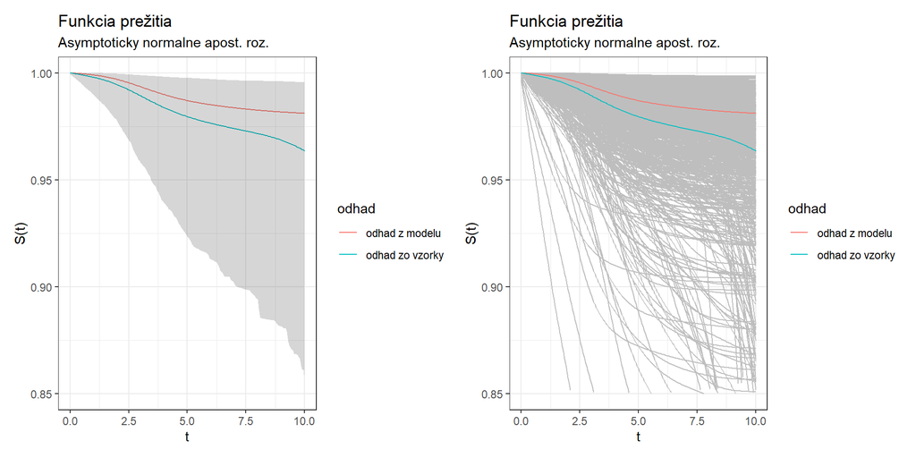

```r
par(mfrow = c(1, 1))

# Vzorka rizikovej funkcie lambda
linear_predictor_sample <- X %*% t(beta1)
lambda_sample <- exp(linear_predictor_sample) * 0.05
# nasobenie 0.05 kvoli offsetu

# Vzorka kumulativnej funkcie rizika H
cum_hazard_sample <- apply(lambda_sample, 2, cumsum) * 0.05

# Vzorka funkcie prezitia S
surv_sample <- exp(-cum_hazard_sample)

# Vykreslenie 1
df_surv_est <- data.frame(
  t1 = c(t1_seq, t1_seq),
  surv_est = c(surv_est_mod2, apply(surv_sample, 1, mean)),
  odhad = rep(c("odhad z modelu", "odhad zo vzorky"),
              each = length(t1_seq))
)
df_surv_CI <- data.frame(
  t1 = t1_seq,
  surv_l95 = apply(surv_sample, 1, quantile, probs = .025),
  surv_u95 = apply(surv_sample, 1, quantile, probs = .975)
)
p1 <- df_surv_est |>
  ggplot(aes(x = t1, y = surv_est, color = odhad)) +
  geom_step() +
  geom_ribbon(data = df_surv_CI,
              aes(x = t1, ymin = surv_l95, ymax = surv_u95),
              alpha = 0.2,
              inherit.aes = FALSE) +
  ylim(c(0.85, 1)) +
  labs(
    x = "t",
    y = "S(t)",
    title = "Funkcia prežitia",
    subtitle = "Asymptoticky normalne apost. roz.") +
  theme_bw()

# Vykreslenie 2
df_surv_est <- data.frame(
  t1 = c(t1_seq, t1_seq),
  surv_est = c(surv_est_mod2, apply(surv_sample, 1, mean)),
  odhad = rep(c("odhad z modelu", "odhad zo vzorky"),
              each = length(t1_seq))
)
df_surv_sample <- data.frame(
  t1 = t1_seq,
  surv = c(surv_sample),
  sample = rep(1:dim(surv_sample)[2], each = dim(surv_sample)[1])
)
p2 <- df_surv_sample |>
  ggplot(aes(x = t1, y = surv, group = sample)) +
  geom_line(color = "gray") +
  geom_step(data = df_surv_est,
            aes(x = t1, y = surv_est, color = odhad),
            inherit.aes = FALSE) +
  ylim(c(0.85, 1)) +
  labs(
    x = "t",
    y = "S(t)",
    title = "Funkcia prežitia",
    subtitle = "Asymptoticky normalne apost. roz.") +
  theme_bw()

p1 + p2
```